# Regresión Lineal

Diplomado en inteligencia artificial y aprendizaje produnfo

Universidad Nacional de Colombia - Bogotá

Elaborado por: Juan José Pineda Cruz

Año: 2021

### 0. Temario

1. Introducción.
2. Breve historia.
3. El planteamiento del algortimo.
4. Desarrollar un ejemplo de regresión lineal, con datos reales.
5. Conclusiones.

### 1. Introducción

El modelo de regresión lineal consiste en la estimación de una función lineal que relacione una variable dependiente $ y $ a partir de unas variables independientes o predictoras ($X_{1},X_{2},...X_{n} $). Dicha función puede estar representada así:

$$ y = w_{i}X_{i} + b $$

En general, este modelo tiene diversas aplicaciones y es una de las formas más sencillas en el aprendizaje de máquinas, siendo un muy buen punto de partida para el aprendizaje y entendimiento de la inteligencia artificial.

Para poder encontrar los valores de $ w_{i} $, existen diferentes estrategias como los Mínimos Cuadrados Ordinarios (MCO) o métodos iterativos más recientes como el Gradiente Descendiente. En ambos casos, se busca minimizar los errores de la estimación.

### 2. Historia

El origen de la noción de regresión proviene, en gran parte, de áreas del conocimiento como Biología y Eugenesia (Castro, Gea, Cañadas & Contreras, 2012) [1] . El primer autor que se interesa en el tema fue LambertAdolphe-Jacques Quetelet quien en sus estudios relaciona dos o más variables, por ejemplo llega a obtener una ecuación de una hipérbola que relaciona la edad y la altura de las personas entre cero y 30 años.

Sin embargo, el término regresión fue introducido por Galton en su libro “Natural inheritance” (1889) refiriéndose a la “ley de la regresión universal”; su trabajo se centraba en la descripción de los rasgos físicos de los descendientes (una variable) a partir de los de sus padres (otra variable) (Contreras & del Pino, n.d.) [2]

Las ideas modernas sobre regresión se originan en los trabajo de Legendre y Gauss, sobre el método de mínimos cuadrados, para ajustar los datos sobre las órbitas de cuerpos celestes. El primer estudio documentado sobre el método de mínimos cuadrados, de donde deriva la idea de regresión, es debido a Legendre (1752-1833) en 1805.

En la siguiente lámina se puede ver una representación gráfica de la recta de regresión con 2 variables.

[figure not shown]

[Fuente](http://blog.iwco.co/content/images/2019/12/GrafRegr-1.png)

En la anterior figura, se tienen graficados los datos del tamaño del inmueble y el precio asociado a dicho inmueble.

### 3. El algoritmo de regresión lineal

El modelo de regresión lineal puede ser un modelo simple, en el caso en elq ue solo tenemos una variable predictora o múltiple si tenemos 2 o más de estas variables. Para generalizar, se puede decir que el modelo de regresión lineal puede representarse con la siguiente ecuación:

$$ Y =w_0 + w_1x_1 + w_2x_2 + ... + \epsilon $$

donde,

$w_i:$ representa los pesos de las variables predictoras o explicativas.

$x_i:$ representa las variables represoras o predictoras.

$\epsilon:$ un término de error aleatorio que corresponde a los factores no medibles por las variables $x_i$.

El modelo de regresión lineal múltiple puede ser representado en forma matricial y la solución para encontrar los pesos de $w_i$ se puede representar como la siguiente ecuación matricial:

$$ w_i = (X^TX)^{-1}X^TY $$

### 4. Una aplicación sobre datos reales

Ahora bien, vamos a realizar una aplicación real sobre un conjunto de datos para poder realizar predicciones sobre una variable a partir de un conjunto de variables. El conjunto de datos que se va a usar se obtuvo del Repositorio de aprendizaje automático de la [UCI](https://archive.ics.uci.edu/ml/index.php). Irvine, CA: Universidad de California, Facultad de Información y Ciencias de la Computación, puntualmente el dataset: "Automobile Data Set". [3]

Este conjunto de datos consta de tres tipos de entidades: (a) la especificación de un automóvil en términos de diversas características, (b) su calificación de riesgo de seguro asignada, (c) sus pérdidas normalizadas en uso en comparación con otros automóviles. La segunda calificación corresponde al grado en que el automóvil es más riesgoso de lo que indica su precio. Inicialmente, a los automóviles se les asigna un símbolo de factor de riesgo asociado con su precio. Luego, si es más arriesgado (o menos), este símbolo se ajusta moviéndolo hacia arriba (o hacia abajo) en la escala. Los actuarios llaman a este proceso "simbolizar". Un valor de +3 indica que el automóvil es riesgoso, -3 que probablemente sea bastante seguro.

El tercer factor es el pago de pérdida promedio relativo por año del vehículo asegurado. Este valor está normalizado para todos los automóviles dentro de una clasificación de tamaño particular (dos puertas pequeñas, camionetas, deportes / especialidades, etc.) y representa la pérdida promedio por automóvil por año.

1. symboling: -3, -2, -1, 0, 1, 2, 3.
2. Pérdidas normalizadas: continuas de 65 a 256.
3. Marca : alfa-romero, audi, bmw, chevrolet , esquivar, honda, isuzu, jaguar, mazda, mercedes-benz, mercury, mitsubishi, nissan, peugot, plymouth, porsche, renault, saab, subaru, toyota, volkswagen, volvo
4. tipo de combustible: diesel, gas.
5. aspiración: estándar, turbo.
6. número de puertas: cuatro, dos.
7. estilo de carrocería: hardtop, wagon, sedán, hatchback, convertible.
8. ruedas motrices: 4wd, fwd, rwd.
9. ubicación del motor: delantero, trasero.
10. Base de ruedas: continua de 86,6 a 120,9.
11. longitud: continua de 141,1 a 208,1.
12. ancho: continuo de 60,3 a 72,3.
13. altura: continua de 47,8 a 59,8.
14. peso en vacío: continuo de 1488 a 4066.
15. tipo de motor: dohc, dohcv, l, ohc, ohcf, ohcv, rotor.
16. número de cilindros: ocho, cinco, cuatro, seis, tres, doce, dos.
17. tamaño del motor: continuo de 61 a 326.
18. sistema de combustible: 1bbl, 2bbl, 4bbl, idi, mfi, mpfi, spdi, spfi.
19. diámetro: continuo de 2,54 a 3,94.
20. carrera: continua de 2,07 a 4,17.
21. relación de compresión: continua de 7 a 23.
22. caballos de fuerza: continua de 48 a 288.
23. rpm pico: continua de 4150 a 6600.
24. mpg en ciudad: continua de 13 a 49.
25. mpg en autopista: continuo de 16 a 54.
26. precio: continuo de 5118 a 45400.

A partir de las variables vamos a tratar de predecir el precio del automovil de acuerdo a ciertas caracterísiticas. Inicialmente, se realizará una regresión lineal simple, luego una regresión lineal con dos variables y finalmente una regresión lineal con todas las variables. Cabe resaltar que existen metodologías para reducir dimencionalidad (como PCA) sin embargo, no serán el calcance del presente notebook.

Los pasos que vamos a seguir son:

1. Carga y exploración de los datos
2. Preprocesamiento, limpieza y transformación
3. Modelamiento: Regresión lineal con Sklearn
4. Validación

#### 4.1 Carga y exploración de los datos

```python
#Importar las librerias que vamos a usar

import numpy as np  # linear algebra
import pandas as pd # data processing, CSV file read
import matplotlib.pyplot as plt # plotting
import seaborn as sns           # plotting
import os
import warnings
warnings.filterwarnings('ignore')
```

```python
#Importar datos
path = os.getcwd() ##obtener la ruta del notebook actual
db = pd.read_csv(path+'\\data\\cars-dataset.txt') #Cargar los datos
db.head(5) #mostrar las primeras 5 filas.
```

|  | normalized_losses | make | fuel_type | aspiration | num_of_doors | body_style | drive_wheels | engine_location | wheel_base | length | ... | engine_size | fuel_system | bore | stroke | compression_ratio | horsepower | peak_rpm | city_mpg | highway_mpg | price |
| --- | --- | --- | --- | --- | --- | --- | --- | --- | --- | --- | --- | --- | --- | --- | --- | --- | --- | --- | --- | --- | --- |
| 3 | ? | alfa-romero | gas | std | two | convertible | rwd | front | 88.6 | 168.8 | ... | 130 | mpfi | 3.47 | 2.68 | 9.0 | 111 | 5000 | 21 | 27 | 13495 |
| 3 | ? | alfa-romero | gas | std | two | convertible | rwd | front | 88.6 | 168.8 | ... | 130 | mpfi | 3.47 | 2.68 | 9.0 | 111 | 5000 | 21 | 27 | 16500 |
| 1 | ? | alfa-romero | gas | std | two | hatchback | rwd | front | 94.5 | 171.2 | ... | 152 | mpfi | 2.68 | 3.47 | 9.0 | 154 | 5000 | 19 | 26 | 16500 |
| 2 | 164 | audi | gas | std | four | sedan | fwd | front | 99.8 | 176.6 | ... | 109 | mpfi | 3.19 | 3.40 | 10.0 | 102 | 5500 | 24 | 30 | 13950 |
| 2 | 164 | audi | gas | std | four | sedan | 4wd | front | 99.4 | 176.6 | ... | 136 | mpfi | 3.19 | 3.40 | 8.0 | 115 | 5500 | 18 | 22 | 17450 |

5 rows × 25 columns

```python
filcol = db.shape
print("El dataset db tiene " + str(filcol[0]) + " filas y " + str(filcol[1]) + " columnas.")
```

```
El dataset db tiene 205 filas y 25 columnas.
```

```python
db.info()
```

```
<class 'pandas.core.frame.DataFrame'>
Int64Index: 205 entries, 3 to -1
Data columns (total 25 columns):
 #   Column             Non-Null Count  Dtype
---  ------             --------------  -----
 0   normalized_losses  205 non-null    object
 1   make               205 non-null    object
 2   fuel_type          205 non-null    object
 3   aspiration         205 non-null    object
 4   num_of_doors       205 non-null    object
 5   body_style         205 non-null    object
 6   drive_wheels       205 non-null    object
 7   engine_location    205 non-null    object
 8   wheel_base         205 non-null    float64
 9   length             205 non-null    float64
```

[output cut: 17 more lines]

Del total de variables en el dataset se tienen 16 tipo objetc, 5 float y 4 integer. Sin embargo, resulta curioso que variables como horsepower estén catalogadas como object. Adicional, no hay ninguna variable con valores null, lo cual también resulta curioso. Posiblemente utilizaron un caracter para calificar los missing. En la observación de head(5) se pueden observar el caracter ?. Por tanto es necesario realizar un tratamiento a estas variables.

Por lo anterior, vamos a realizar una modificación en el cargue de los datos. Con el indicador de na (missing) = "?"

```python
db = pd.read_csv(path+'\\data\\cars-dataset.txt',  na_values = '?') #Cargar los datos
```

```python
db.info()
```

```
<class 'pandas.core.frame.DataFrame'>
Int64Index: 205 entries, 3 to -1
Data columns (total 25 columns):
 #   Column             Non-Null Count  Dtype
---  ------             --------------  -----
 0   normalized_losses  164 non-null    float64
 1   make               205 non-null    object
 2   fuel_type          205 non-null    object
 3   aspiration         205 non-null    object
 4   num_of_doors       203 non-null    object
 5   body_style         205 non-null    object
 6   drive_wheels       205 non-null    object
 7   engine_location    205 non-null    object
 8   wheel_base         205 non-null    float64
 9   length             205 non-null    float64
```

[output cut: 17 more lines]

```python
db.describe()
```

|  | normalized_losses | wheel_base | length | width | height | curb_weight | engine_size | bore | stroke | compression_ratio | horsepower | peak_rpm | city_mpg | highway_mpg | price |
| --- | --- | --- | --- | --- | --- | --- | --- | --- | --- | --- | --- | --- | --- | --- | --- |
| count | 164.000000 | 205.000000 | 205.000000 | 205.000000 | 205.000000 | 205.000000 | 205.000000 | 201.000000 | 201.000000 | 205.000000 | 203.000000 | 203.000000 | 205.000000 | 205.000000 | 201.000000 |
| mean | 122.000000 | 98.756585 | 174.049268 | 65.907805 | 53.724878 | 2555.565854 | 126.907317 | 3.329751 | 3.255423 | 10.142537 | 104.256158 | 5125.369458 | 25.219512 | 30.751220 | 13207.129353 |
| std | 35.442168 | 6.021776 | 12.337289 | 2.145204 | 2.443522 | 520.680204 | 41.642693 | 0.273539 | 0.316717 | 3.972040 | 39.714369 | 479.334560 | 6.542142 | 6.886443 | 7947.066342 |
| min | 65.000000 | 86.600000 | 141.100000 | 60.300000 | 47.800000 | 1488.000000 | 61.000000 | 2.540000 | 2.070000 | 7.000000 | 48.000000 | 4150.000000 | 13.000000 | 16.000000 | 5118.000000 |
| 25% | 94.000000 | 94.500000 | 166.300000 | 64.100000 | 52.000000 | 2145.000000 | 97.000000 | 3.150000 | 3.110000 | 8.600000 | 70.000000 | 4800.000000 | 19.000000 | 25.000000 | 7775.000000 |
| 50% | 115.000000 | 97.000000 | 173.200000 | 65.500000 | 54.100000 | 2414.000000 | 120.000000 | 3.310000 | 3.290000 | 9.000000 | 95.000000 | 5200.000000 | 24.000000 | 30.000000 | 10295.000000 |
| 75% | 150.000000 | 102.400000 | 183.100000 | 66.900000 | 55.500000 | 2935.000000 | 141.000000 | 3.590000 | 3.410000 | 9.400000 | 116.000000 | 5500.000000 | 30.000000 | 34.000000 | 16500.000000 |
| max | 256.000000 | 120.900000 | 208.100000 | 72.300000 | 59.800000 | 4066.000000 | 326.000000 | 3.940000 | 4.170000 | 23.000000 | 288.000000 | 6600.000000 | 49.000000 | 54.000000 | 45400.000000 |

#### 4.2. Preprocesamiento, limpieza, transformación y visualización inicial

Ahora bien, dentro del proceso de preprocesamiento, es importante validar que los valores de las variables object sean consistentes y estén estandarizados. Un sólo caracter diferente como una tílde, un espacio o signo de puntualción pueden cambiar su valor. Vamos a revisar esto.

```python
##Variables tipo object para evidencias sus valores unicos

##Seleccionar solo las columnas de tipo objet = 'O'
listobj =[]
columns = db.columns

#ingresar a la lista unicamente los nombres de las columnas con tipo object
for variable in columns:
    if db[variable].dtype=='O':
        listobj.append(variable)

for variable in listobj:
    valores_unicos=db[variable].unique()
    print(valores_unicos)
```

```
['alfa-romero' 'audi' 'bmw' 'chevrolet' 'dodge' 'honda' 'isuzu' 'jaguar'
 'mazda' 'mercedes-benz' 'mercury' 'mitsubishi' 'nissan' 'peugot'
 'plymouth' 'porsche' 'renault' 'saab' 'subaru' 'toyota' 'volkswagen'
 'volvo']
['gas' 'diesel']
['std' 'turbo']
['two' 'four' nan]
['convertible' 'hatchback' 'sedan' 'wagon' 'hardtop']
['rwd' 'fwd' '4wd']
['front' 'rear']
['dohc' 'ohcv' 'ohc' 'l' 'rotor' 'ohcf' 'dohcv']
['four' 'six' 'five' 'three' 'twelve' 'two' 'eight']
['mpfi' '2bbl' 'mfi' '1bbl' 'spfi' '4bbl' 'idi' 'spdi']
```

Todas las variables tienen valores únicos (variables tipo Object). Podemos continuar con nuestro análisis.

```python
##Missing values
#Debemos revisar el porcentaje de los missing en cada variable. Creamos una función que retorne una tabla con las variables, y porcentajes mayores a cero.
def tabla_missing(db):
    is_null = db.isnull().sum().sort_values(ascending=False) #Validar si una variable tiene missing en alguno de sus valores y sumarlos (total missing)
    porc = ((db.isnull().sum()/db.isnull().count()).sort_values(ascending=False))*100

    missing_data = pd.concat([is_null, round(porc,2)], axis=1, keys=['Total', 'Percent'])
    return missing_data[missing_data.Percent>0] #Imprimir sólo las variables con porcentaje de missing mayores a cero
```

```python
#Invocar la función anteriormente creada
tabla_missing(db)
```

|  | Total | Percent |
| --- | --- | --- |
| normalized_losses | 41 | 20.00 |
| stroke | 4 | 1.95 |
| bore | 4 | 1.95 |
| price | 4 | 1.95 |
| horsepower | 2 | 0.98 |
| peak_rpm | 2 | 0.98 |
| num_of_doors | 2 | 0.98 |

```python
#Realizamos una imputación de datos con el promedio para las variables normalized_losses, stroke, bore.

db['normalized_losses'].fillna(db['normalized_losses'].mean(), inplace=True)
db['stroke'].fillna(db['stroke'].mean(), inplace=True)
db['bore'].fillna(db['bore'].mean(), inplace=True)

#eliminamos las demás registros con missing de las otras variables:

db.dropna(subset=['price'], axis=0, inplace=True)
db.dropna(subset=['horsepower'], axis=0, inplace=True)
db.dropna(subset=['peak_rpm'], axis=0, inplace=True)
db.dropna(subset=['num_of_doors'], axis=0, inplace=True)
```

```python
#Validar que no haya variables con missing
tabla_missing(db)
```

|  | Total | Percent |
| --- | --- | --- |

#### 4.3.1 Visualización de datos

##### 4.3.1.1 Visualización de la variable target

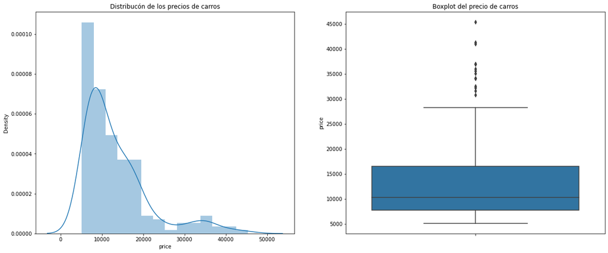

```python
#Variable de interés (Y): price

plt.figure(figsize=(20,8))
plt.subplot(1,2,1)
plt.title('Distribucón de los precios de carros')
sns.distplot(db.price)

plt.subplot(1,2,2)
plt.title('Boxplot del precio de carros')
sns.boxplot(y=db.price)

plt.show()
```

Se evidencia que la mediana está cercana a los 10.000 USD. existe una concentración apreciable de los datos del precio de los carros hacia los 16.000 USG (percentil 75%).

##### 4.3.1.2 Visualización de las variables categóricas

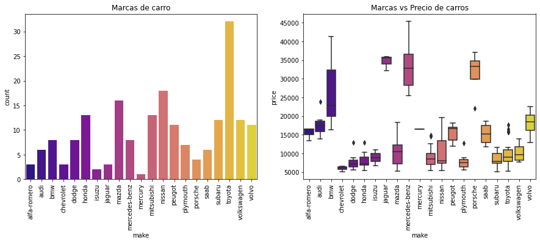

```python
#Marca de carro
plt.figure(figsize=(15,5))

plt.subplot(1,2,1)
plt.title('Marcas de carro')
ax=sns.countplot(db.make, palette=("plasma"))
plt.setp(ax.get_xticklabels(), rotation=90)
plt.subplot(1,2,2)
plt.title('Marcas vs Precio de carros')
ax=sns.boxplot(x=db.make, y=db.price, palette=("plasma"))
plt.setp(ax.get_xticklabels(), rotation=90)
plt.show()
```

Se evidencia una concentración en autos de la marca Toyota. Adicional, al relacionar la marca del carro con su precio, es evidente que existe una categoría premium de carros compuesta por las marcas: BMW, Jaguar, Mercedes-benz, Porsche. Efectivamente, era un resultado esperado y evidente en los boxplot del precio por marca de carro.

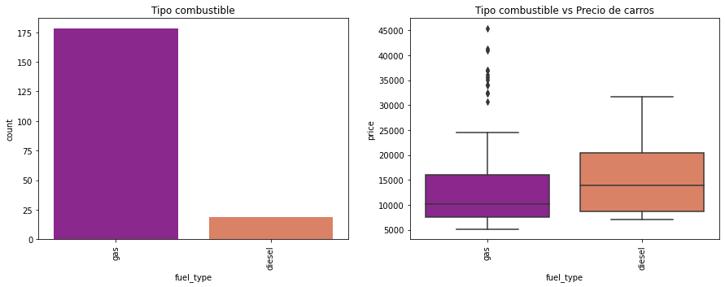

```python
#Fuel_type

#Marca de carro
plt.figure(figsize=(15,5))

plt.subplot(1,2,1)
plt.title('Tipo combustible')
ax=sns.countplot(db.fuel_type, palette=("plasma"))
plt.setp(ax.get_xticklabels(), rotation=90)
plt.subplot(1,2,2)
plt.title('Tipo combustible vs Precio de carros')
ax=sns.boxplot(x=db.fuel_type, y=db.price, palette=("plasma"))
plt.setp(ax.get_xticklabels(), rotation=90)
plt.show()
```

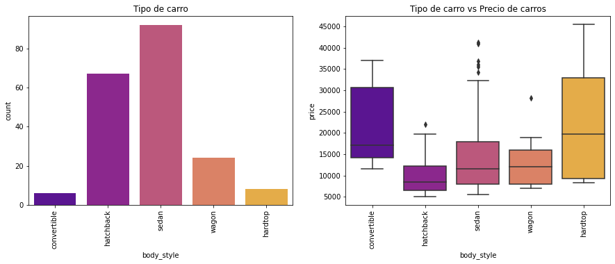

```python
#body_style
plt.figure(figsize=(15,5))

plt.subplot(1,2,1)
plt.title('Tipo de carro')
ax=sns.countplot(db.body_style, palette=("plasma"))
plt.setp(ax.get_xticklabels(), rotation=90)
plt.subplot(1,2,2)
plt.title('Tipo de carro vs Precio de carros')
ax=sns.boxplot(x=db.body_style, y=db.price, palette=("plasma"))
plt.setp(ax.get_xticklabels(), rotation=90)
plt.show()
```

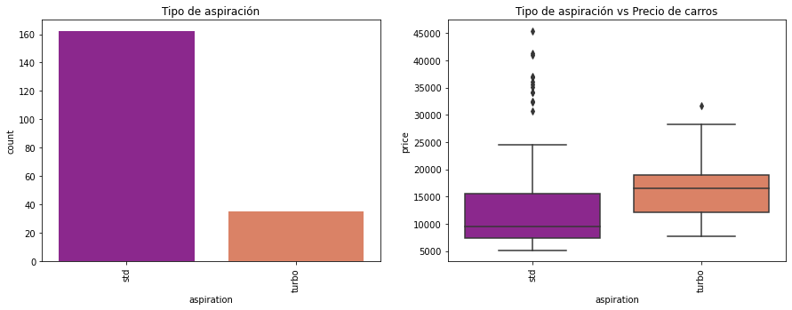

```python
#aspiration
plt.figure(figsize=(15,5))

plt.subplot(1,2,1)
plt.title('Tipo de aspiración')
ax=sns.countplot(db.aspiration, palette=("plasma"))
plt.setp(ax.get_xticklabels(), rotation=90)
plt.subplot(1,2,2)
plt.title('Tipo de aspiración vs Precio de carros')
ax=sns.boxplot(x=db.aspiration, y=db.price, palette=("plasma"))
plt.setp(ax.get_xticklabels(), rotation=90)
plt.show()
```

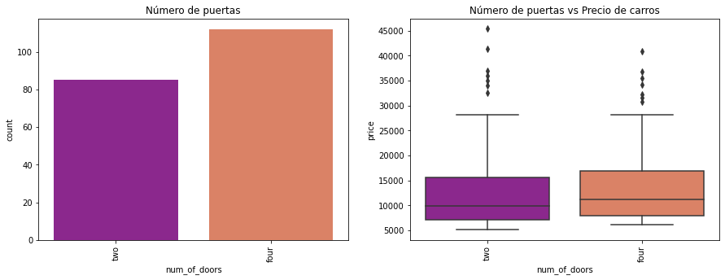

```python
#num_of_doors
plt.figure(figsize=(15,5))

plt.subplot(1,2,1)
plt.title('Número de puertas')
ax=sns.countplot(db.num_of_doors, palette=("plasma"))
plt.setp(ax.get_xticklabels(), rotation=90)
plt.subplot(1,2,2)
plt.title('Número de puertas vs Precio de carros')
ax=sns.boxplot(x=db.num_of_doors, y=db.price, palette=("plasma"))
plt.setp(ax.get_xticklabels(), rotation=90)
plt.show()
```

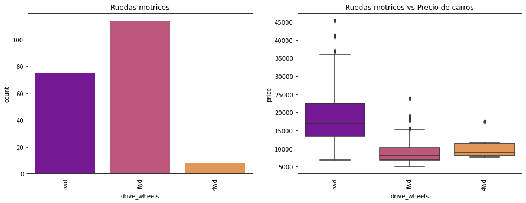

```python
#drive_wheels
plt.figure(figsize=(15,5))

plt.subplot(1,2,1)
plt.title('Ruedas motrices')
ax=sns.countplot(db.drive_wheels, palette=("plasma"))
plt.setp(ax.get_xticklabels(), rotation=90)
plt.subplot(1,2,2)
plt.title('Ruedas motrices vs Precio de carros')
ax=sns.boxplot(x=db.drive_wheels, y=db.price, palette=("plasma"))
plt.setp(ax.get_xticklabels(), rotation=90)
plt.show()
```

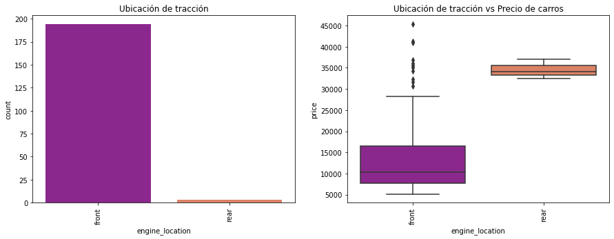

```python
#engine_location
plt.figure(figsize=(15,5))

plt.subplot(1,2,1)
plt.title('Ubicación de tracción')
ax=sns.countplot(db.engine_location, palette=("plasma"))
plt.setp(ax.get_xticklabels(), rotation=90)
plt.subplot(1,2,2)
plt.title('Ubicación de tracción vs Precio de carros')
ax=sns.boxplot(x=db.engine_location, y=db.price, palette=("plasma"))
plt.setp(ax.get_xticklabels(), rotation=90)
plt.show()
```

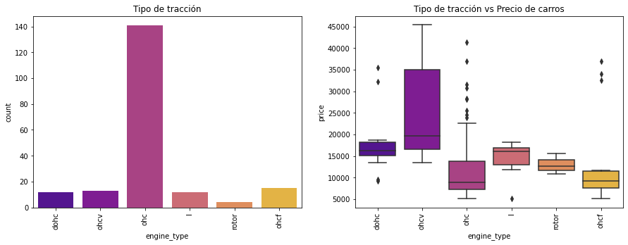

```python
#engine_type
plt.figure(figsize=(15,5))

plt.subplot(1,2,1)
plt.title('Tipo de tracción')
ax=sns.countplot(db.engine_type, palette=("plasma"))
plt.setp(ax.get_xticklabels(), rotation=90)
plt.subplot(1,2,2)
plt.title('Tipo de tracción vs Precio de carros')
ax=sns.boxplot(x=db.engine_type, y=db.price, palette=("plasma"))
plt.setp(ax.get_xticklabels(), rotation=90)
plt.show()
```

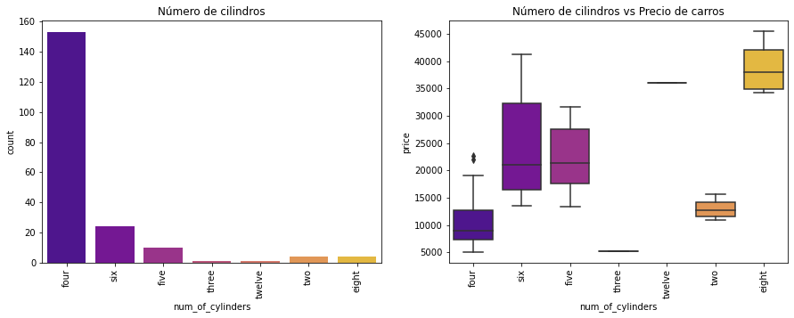

```python
#num_of_cylinders
plt.figure(figsize=(15,5))

plt.subplot(1,2,1)
plt.title('Número de cilindros')
ax=sns.countplot(db.num_of_cylinders, palette=("plasma"))
plt.setp(ax.get_xticklabels(), rotation=90)
plt.subplot(1,2,2)
plt.title('Número de cilindros vs Precio de carros')
ax=sns.boxplot(x=db.num_of_cylinders, y=db.price, palette=("plasma"))
plt.setp(ax.get_xticklabels(), rotation=90)
plt.show()
```

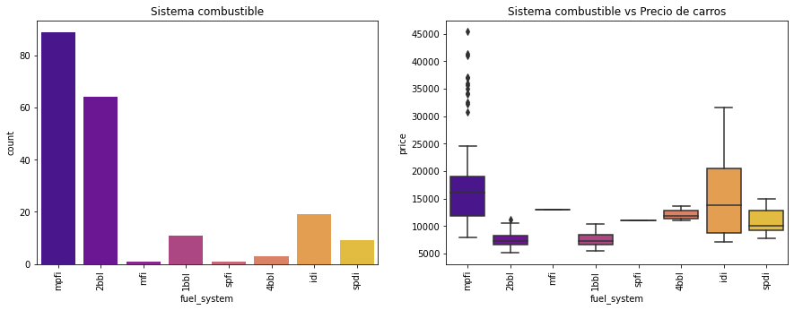

```python
#fuel_system
plt.figure(figsize=(15,5))

plt.subplot(1,2,1)
plt.title('Sistema combustible')
ax=sns.countplot(db.fuel_system, palette=("plasma"))
plt.setp(ax.get_xticklabels(), rotation=90)
plt.subplot(1,2,2)
plt.title('Sistema combustible vs Precio de carros')
ax=sns.boxplot(x=db.fuel_system, y=db.price, palette=("plasma"))
plt.setp(ax.get_xticklabels(), rotation=90)
plt.show()
```

##### 4.3.1.3 Visualización de las variables numéricas

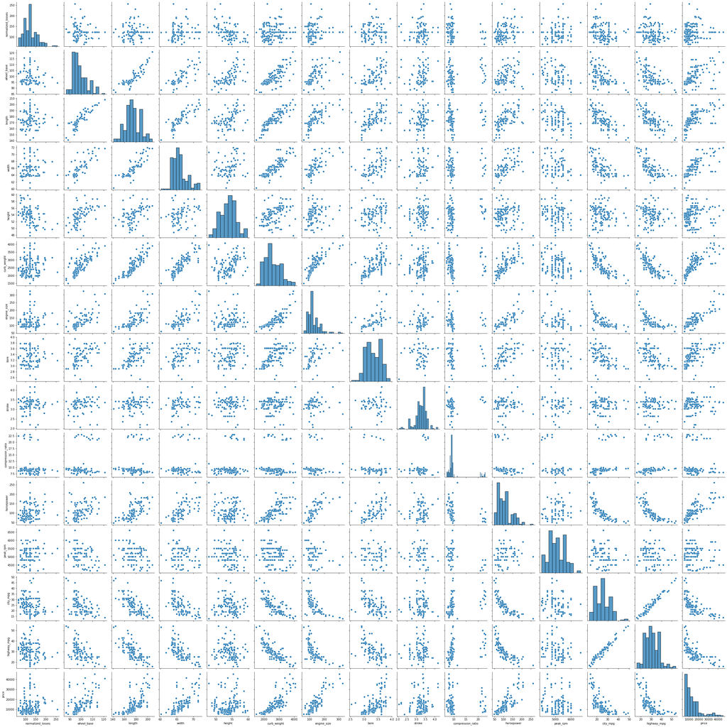

```python
sns.pairplot(db)
```

Ahora es necesario convertir en variables dummy todas las variables categóricas:

```python
encode = pd.get_dummies(db[listobj]) #En unas celdas arriba se habia construido una lista con las bariables de tipo object
```

```python
db = pd.concat([db, encode], axis=1) #agregar todas las dummy al dataset db
```

```python
db.drop(listobj, axis=1, inplace=True) #eliminar del datset la lista de variables categoricas (object)
```

```python
db.head(5)
```

|  | normalized_losses | wheel_base | length | width | height | curb_weight | engine_size | bore | stroke | compression_ratio | ... | num_of_cylinders_twelve | num_of_cylinders_two | fuel_system_1bbl | fuel_system_2bbl | fuel_system_4bbl | fuel_system_idi | fuel_system_mfi | fuel_system_mpfi | fuel_system_spdi | fuel_system_spfi |
| --- | --- | --- | --- | --- | --- | --- | --- | --- | --- | --- | --- | --- | --- | --- | --- | --- | --- | --- | --- | --- | --- |
| 3 | 122.0 | 88.6 | 168.8 | 64.1 | 48.8 | 2548 | 130 | 3.47 | 2.68 | 9.0 | ... | 0 | 0 | 0 | 0 | 0 | 0 | 0 | 1 | 0 | 0 |
| 3 | 122.0 | 88.6 | 168.8 | 64.1 | 48.8 | 2548 | 130 | 3.47 | 2.68 | 9.0 | ... | 0 | 0 | 0 | 0 | 0 | 0 | 0 | 1 | 0 | 0 |
| 1 | 122.0 | 94.5 | 171.2 | 65.5 | 52.4 | 2823 | 152 | 2.68 | 3.47 | 9.0 | ... | 0 | 0 | 0 | 0 | 0 | 0 | 0 | 1 | 0 | 0 |
| 2 | 164.0 | 99.8 | 176.6 | 66.2 | 54.3 | 2337 | 109 | 3.19 | 3.40 | 10.0 | ... | 0 | 0 | 0 | 0 | 0 | 0 | 0 | 1 | 0 | 0 |
| 2 | 164.0 | 99.4 | 176.6 | 66.4 | 54.3 | 2824 | 136 | 3.19 | 3.40 | 8.0 | ... | 0 | 0 | 0 | 0 | 0 | 0 | 0 | 1 | 0 | 0 |

5 rows × 73 columns

```python
filcol = db.shape
print("El dataset db tiene " + str(filcol[0]) + " filas y " + str(filcol[1]) + " columnas.")
```

```
El dataset db tiene 197 filas y 73 columnas.
```

#### 4.3. Modelamiento: Regresión lineal con Sklearn

##### 4.3.1 Separación en train y test datasets

```python
from sklearn.model_selection import train_test_split

np.random.seed(123) #definir una semilla
db_train, db_test = train_test_split(db, train_size = 0.7, test_size = 0.3, random_state = 100)
```

```python
db_train.shape
```

```
(137, 73)
```

```python
db_test.shape
```

```
(60, 73)
```

##### 4.3.2 Modelo de regresión lineal simple (una variable predictora) con sklearn

Para este caso y de acuerdo con el gráfico de 4.3.1.3, se va a seleccionar la variable engine_size para realizar las predicciones de los precios de los carros en este primer modelo lineal simple.

```python
#Separar la variable para el modelo en 4 nuevas variables: x1_train, y_1_train, x_1_test, y_1_test
x_1_train = db_train['engine_size']
y_1_train = db_train['price']

x_1_test = db_test['engine_size']
y_1_test = db_test['price']
```

```python
#Graficamos la variable predictora y la variable de interés para ver su relación:
```

```python
#Creamos la gráfica
def relation_engine_price(es, price):
  plt.scatter(es, price, alpha=0.25)
  plt.title("Cilindraje contra Precio de carros")
  plt.show()
  return np.corrcoef(es, price)[0, 1]   #  se recibe uma matriz de correlaciones. Se xtrae la correlación
```

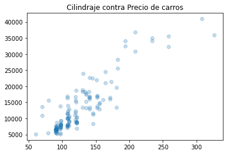

```
La correlación de Cilindraje y Precio de carros es: 0.8833866215066715
```

```python
print("La correlación de Cilindraje y Precio de carros es:", relation_engine_price(x_1_train, y_1_train))
```

```python
#Convertir la variable en un arreglo de 1D (una dimension)
x_1_train = np.array(x_1_train)
x_1_train = x_1_train.reshape(-1,1)

y_1_train = np.array(y_1_train)
y_1_train = y_1_train.reshape(-1,1)

x_1_test = np.array(x_1_test)
x_1_test = x_1_test.reshape(-1,1)

y_1_test = np.array(y_1_test)
y_1_test = y_1_test.reshape(-1,1)
```

```python
from sklearn.linear_model import LinearRegression
lm = LinearRegression()
lm.fit(x_1_train,y_1_train)

print(lm.intercept_)
print(lm.coef_)
```

```
[-7071.38323296]
[[161.0631529]]
```

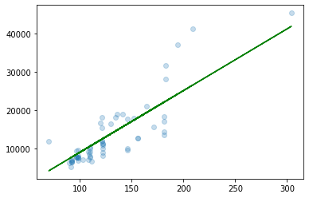

```
Modelo Cilindraje vs precio: w1 = 161.063 w0 = -7071.383 mse = 19120943.496 score = 0.726
```

```python
#Graficar la recta de regresión
y_1_predict = lm.predict(x_1_test)

plt.plot(x_1_test, y_1_predict, color="green")
plt.scatter(x_1_test, y_1_test, alpha=0.25)
plt.show()

from sklearn.metrics import mean_squared_error

fit_intercept_error = mean_squared_error(y_1_test, y_1_predict)

w1= lm.coef_[0]
w0 = lm.intercept_
result_score =lm.score(x_1_test,y_1_test)

print("Modelo Cilindraje vs precio: w1 =", round(w1[0],3), "w0 =",
        round(w0[0],3), "mse =", round(fit_intercept_error,3), "score =", round(result_score,3) )
```

##### 4.3.3 Modelo de regresión lineal múltiple (dos variables predictoras) con sklearn

Ahora se va a ajustar un modelo lineal con 2 variables $w1$ = engine_size y $w2$ = horsepower para estimar el precio de los carros

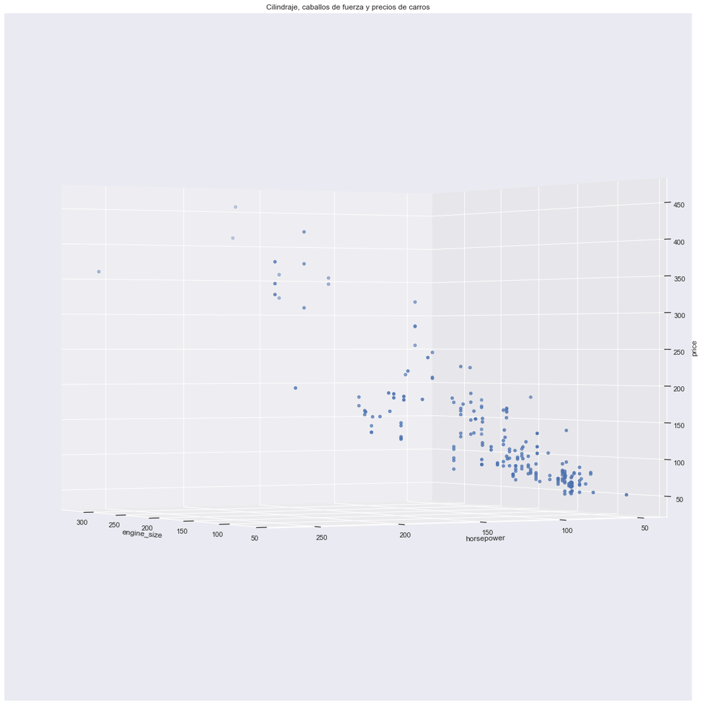

```python
##Graficar en 3D
from mpl_toolkits.mplot3d import Axes3D

sns.set(style = "darkgrid")

fig = plt.figure(figsize=(25,20))
ax = fig.add_subplot(111, projection = '3d')

x = db['engine_size']
y = db['horsepower']
z = db['price']

ax.view_init(elev=0., azim=150)
ax.set_xlabel("engine_size")
ax.set_ylabel("horsepower")
ax.set_zlabel("price")
ax.set_title('Cilindraje, caballos de fuerza y precios de carros')
ax.scatter(x, y, z/100)

plt.show()
```

```python
#Separar la variable para el modelo en 4 nuevas variables: w2_train, y_2_train, w_2_test, y_2_test
w_2_train = np.array(db_train[['engine_size','horsepower']]).reshape(-1, 2)
y_2_train = db_train['price']

w_2_test = db_test[['engine_size','horsepower']]
y_2_test = db_test['price']
```

```python
lm = LinearRegression()
lm.fit(w_2_train,y_2_train)
y_2_predict = lm.predict(w_2_test)


fit_intercept_error = mean_squared_error(y_2_test, y_2_predict)

w1= lm.coef_[0]
w2= lm.coef_[1]
w0 = lm.intercept_
result_score =lm.score(w_2_test,y_2_test)


print("Modelo Cilindraje, caballos de fuerza vs precio: w1 =", round(w1,3), "w2 =", round(w2,3), "w0 =",
       round(w0,3), "mse =", round(fit_intercept_error,3), "score =", round(result_score,3) )
```

```
Modelo Cilindraje, caballos de fuerza vs precio: w1 = 113.141 w2 = 64.983 w0 = -7717.927 mse = 17961655.919 score = 0.742
```

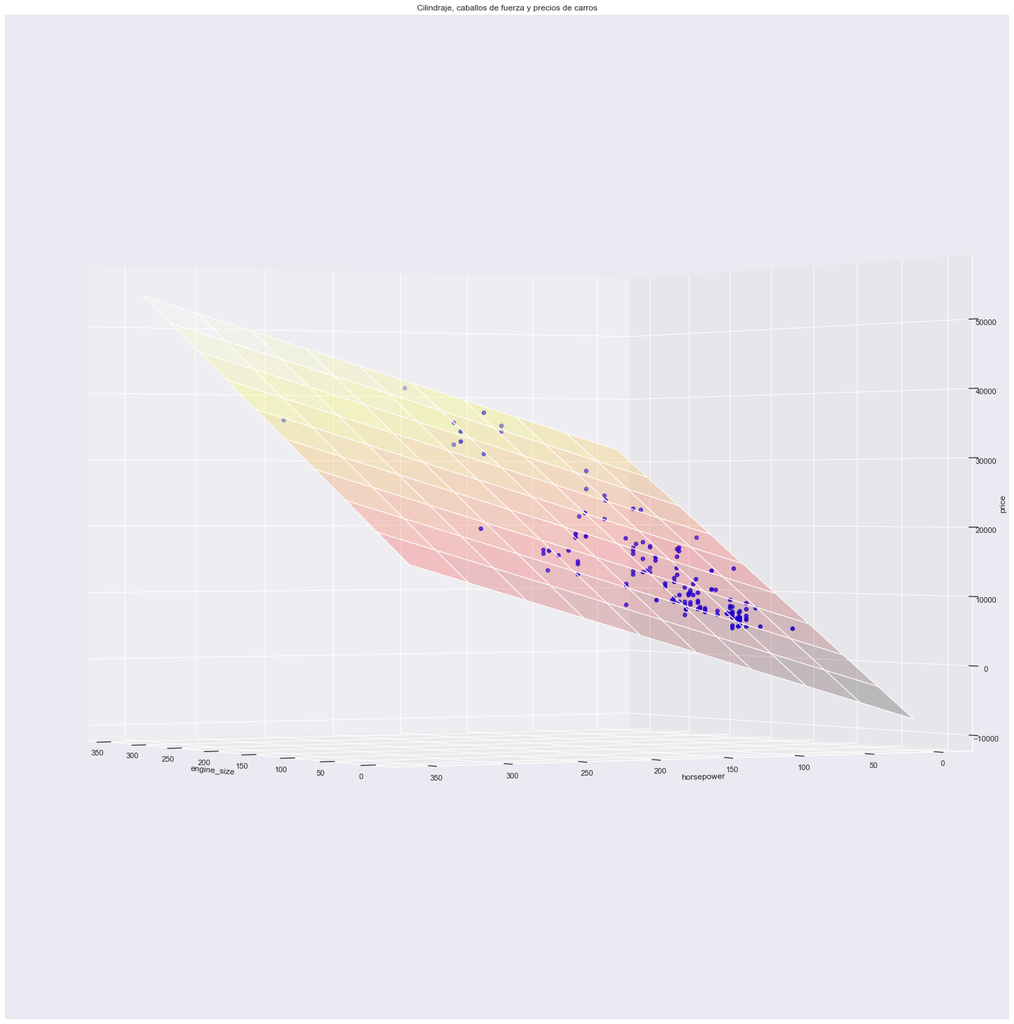

```python
#Graficamos el plano encontrado

fig = plt.figure(figsize=(25,20))
ax = Axes3D(fig)
sns.set(style = "darkgrid")


# Creamos una malla, sobre la cual graficaremos el plano
xx, yy = np.meshgrid(np.linspace(0, 350, num=10), np.linspace(0, 350, num=10))

# calculamos los valores del plano para los puntos x e y
nuevoX = (lm.coef_[0] * xx)
nuevoY = (lm.coef_[1] * yy)

# calcular z con la ecuación z = w0 + w1x1 + w2x2
z = (nuevoX + nuevoY + lm.intercept_)

# Graficar el plano
ax.plot_surface(xx, yy, z, alpha=0.2, cmap='hot')

# Graficar los puntos en 3D
ax.scatter(w_2_train[:, 0], w_2_train[:, 1], y_2_train, c='blue',s=30)



ax.view_init(elev=0., azim=150) #Cambiar la vista de la cáma de 3D
ax.set_xlabel("engine_size")
ax.set_ylabel("horsepower")
ax.set_zlabel("price")
ax.set_title('Cilindraje, caballos de fuerza y precios de carros')
```

##### 4.3.5 Modelo de regresión lineal múltiple (todas las variables predictoras) con sklearn

Es importante resaltar que el objetivo de este notebook no encontrar el mejor modelo de regresión lineal posible sino realizar 3 pruebas con 3 modelos de regresión para los datos de automóviles. En este tercer modelo se van a incluir todas las variables disponibles.

```python
#Separar la variable para el modelo en 4 nuevas variables: w_train, y_train, w_test, y_test
w_train = np.array(db_train.drop(['price'],axis=1)).reshape(-1, 72)
y_train = db_train['price']

w_test = db_test.drop(['price'],axis=1)
y_test = db_test['price']
```

```python
lm = LinearRegression()
lm.fit(w_train,y_train)
y_predict = lm.predict(w_test)


fit_intercept_error = mean_squared_error(y_test, y_predict)

result_score =lm.score(w_test,y_test)



print("Modelo Cilindraje, caballos de fuerza vs precio: score =", round(result_score,3) )
```

```
Modelo Cilindraje, caballos de fuerza vs precio: score = 0.899
```

```python
from sklearn.metrics import mean_absolute_error
#Predecimos en train y test
predictions_train = np.array(lm.predict(w_train)).reshape(-1, 1)
predictions_test = np.array(lm.predict(w_test)).reshape(-1, 1)

y_train = np.array(y_train).reshape(-1, 1)
y_test =  np.array(y_test).reshape(-1, 1)
#Realizamos métricas para comprobar lo buenos que es nuestro modelo
mae_train = mean_absolute_error(predictions_train, y_train)
root_mse_train = np.sqrt(mean_squared_error(predictions_train, y_train))
mae_test = mean_absolute_error(predictions_test,y_test )
root_mse_test = np.sqrt(mean_squared_error(predictions_test, y_test))
r2_score_train = lm.score(w_train, y_train)
r2_score_test = lm.score(w_test,y_test )
```

```python
print(f"Métricas generales del Modelo Cilindraje, caballos de fuerza vs precio:\n MAE train: "
      , round(mae_train,3)
      , "\n MAE Test: ", round(root_mse_test,3)
      , "\n Root MSE train: ", round(root_mse_train,3)
      , "\n Root MSE test: ", round(root_mse_test,3)
      , "\n Score train: ", round(r2_score_train,3)
      , "\n Score test: ", round(r2_score_test,3))
```

```
Métricas generales del Modelo Cilindraje, caballos de fuerza vs precio:
 MAE train:  853.179
 MAE Test:  2649.068
 Root MSE train:  1073.486
 Root MSE test:  2649.068
 Score train:  0.981
 Score test:  0.899
```

### 5. Algunas conclusiones

Se realizaron 3 modelos para ajustar los datos y poder predecir el precio de los carros a partir de unas variables predictoras.

En el primer modelo se utilizó únicamente una variable predictora: el cilindraje, el modelo tuvo un score de ajuste: 0.726. ESe realizó un segundo modelo y se utilizaron 2 variables predictoras: el cilindraje y los caballos de fuerza el modelo tuvo un score de ajuste: 0.742. Se evidencia una leve mejora lo cual era un resultado esperado en la medida que las dos variables estaban correlacionadas con el precio de los carros y mejoraba la capacidad predictora del modelo.

Finalmente, se realiza un modelo con todas las variables, se obtiene un score de 0.899. Se evidencia una mejora considerable. Sin embargo, se observa que existe un posible sobre ajuste en el modelo de entrenamiento ya que el R2 score cambia significativamente de 0.981 a 0.899, al igual que la raíz cuadrada del error cuadrático medio en el train y test. Es importante seguir con estrategias para corregir este inconveniente y poder ajustar un mejor modelo. Sin embargo y tal y como se mencionó a lo largo del notebook, la intención no es ajustar un buen modelo sino realizar pruebas de regresión lineal sobre un conjunto de datos utilizando la librería sklearn en python.

### Bibliografía

[1] Castro, A., Gea, M., Cañadas, G. & Contreras, J. (2012). Algunas notas históricas sobre la correlación y regresión y su uso en el aula. Números: Revista de Didáctica de las Matemáticas. V. 81, noviembre de 2012, páginas 5-14. Revisado 21 Marzo 2021, de https://core.ac.uk/download/pdf/20343739.pdf

[2] Contreras, J., & del Pino, C. Modelos matemáticos y funciones - Método de los mínimos cuadrados [Ebook]. Revisado 21 Marzo 2021, de http://inst-mat.utalca.cl/~cdelpino/modelos/sesion7/regresion-lineal.pdf.

[3] Schlimmer, J. (1987). Automobile Data Set. UCI Machine Learning Repository [http://archive.ics.uci.edu/ml]. Irvine, CA: University of California, School of Information and Computer Science. Revisado 21 Marzo 2021, de https://archive.ics.uci.edu/ml/datasets/Automobile